# Two-symbiont model simulations

Ross Cunning

2/19/2018

# Parameterize sensitive and tolerant symbionts

What we know about “tolerant” symbionts:

- Lower photosynthetic rates
  - Reduce jCPm from 2.8 to 1.0
- Lower ROS production
  - Increase kROS from 80 to 250

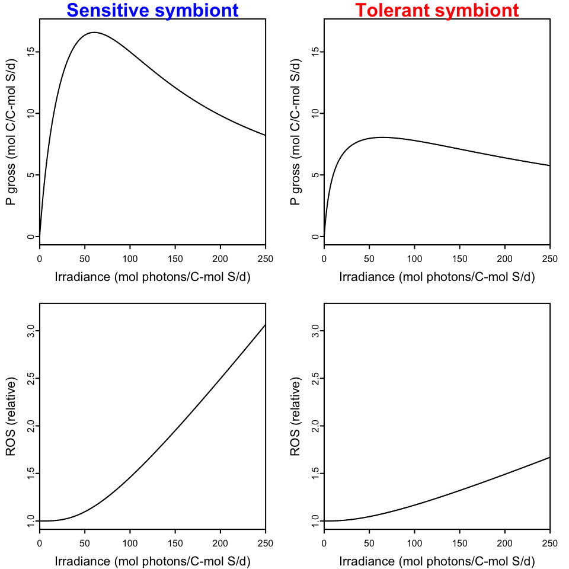

```r
# Sensitive symbiont -- default max. photosynthetic rate and ROS production
ssym <- def_pars(nsym=1)
ssym$jCPm <- 2.8; ssym$kROS <- 80
ssympi <- sym_PI(ssym, draw=FALSE)
# Tolerant symbiont -- lower max. photosynthetic rate, lower ROS production
tsym <- def_pars(nsym=1)
tsym$jCPm <- 1.0; tsym$kROS <- 250
tsympi <- sym_PI(tsym, draw=FALSE)

# Plot Photosynthesis and ROS production for each symbiont as a function of irradiance
par(mfcol=c(2,2), mar=c(2.1,2.1,1,1), mgp=c(1.1,0.1,0), tcl=-0.2, cex.axis=0.6, cex.lab=0.8)
plot(ssympi$jCP/ssym$yCL ~ ssympi$jL, type="l", lwd=1,
     xlab="Irradiance (mol photons/C-mol S/d)",
     ylab="P gross (mol C/C-mol S/d)", ylim=c(0,17),
     main="Sensitive symbiont", col.main="blue")
plot(ssympi$cROS ~ ssympi$jL, type="l", lwd=1,
     xlab="Irradiance (mol photons/C-mol S/d)",
     ylab="ROS (relative)", ylim=c(1,3.2))
plot(tsympi$jCP/tsym$yCL ~ tsympi$jL, type="l", lwd=1,
     xlab="Irradiance (mol photons/C-mol S/d)",
     ylab="P gross (mol C/C-mol S/d)", ylim=c(0,17),
     main="Tolerant symbiont", col.main="red")
plot(tsympi$cROS ~ tsympi$jL, type="l", lwd=1,
     xlab="Irradiance (mol photons/C-mol S/d)",
     ylab="ROS (relative)", ylim=c(1,3.2))
```

PI and ROS production curves are consistent with expectations of a tolerant symbiont: maximum photosynthetic rate is reduced, but photoinhibition and ROS production are reduced at high light levels. But what is their behavior when we put these symbionts into a coral host?